# sPlot – A new tool for global vegetation analyses - Bruelheide - 2019 - Journal of Vegetation Science - Wiley Online Library

[Journal of Vegetation Science](https://onlinelibrary.wiley.com/journal/16541103)

[Volume 30, Issue 2](https://onlinelibrary.wiley.com/toc/16541103/2019/30/2) p. 161-186

REPORT

Open Access

# sPlot – A new tool for global vegetation analyses

[Helge Bruelheide](https://onlinelibrary.wiley.com/action/doSearch?ContribAuthorStored=Bruelheide%2C+Helge),

These authors should be considered joint first authors.

[Jürgen Dengler](https://onlinelibrary.wiley.com/action/doSearch?ContribAuthorStored=Dengler%2C+J%C3%BCrgen),

These authors should be considered joint first authors.

[Borja Jiménez-Alfaro](https://onlinelibrary.wiley.com/action/doSearch?ContribAuthorStored=Jim%C3%A9nez-Alfaro%2C+Borja),

These authors should be considered joint first authors.

[Oliver Purschke](https://onlinelibrary.wiley.com/action/doSearch?ContribAuthorStored=Purschke%2C+Oliver),

These authors should be considered joint first authors.

[Stephan M. Hennekens](https://onlinelibrary.wiley.com/action/doSearch?ContribAuthorStored=Hennekens%2C+Stephan+M),

[Milan Chytrý](https://onlinelibrary.wiley.com/action/doSearch?ContribAuthorStored=Chytr%C3%BD%2C+Milan),

[Valério D. Pillar](https://onlinelibrary.wiley.com/action/doSearch?ContribAuthorStored=Pillar%2C+Val%C3%A9rio+D),

[Florian Jansen](https://onlinelibrary.wiley.com/action/doSearch?ContribAuthorStored=Jansen%2C+Florian),

[Jens Kattge](https://onlinelibrary.wiley.com/action/doSearch?ContribAuthorStored=Kattge%2C+Jens),

[Brody Sandel](https://onlinelibrary.wiley.com/action/doSearch?ContribAuthorStored=Sandel%2C+Brody),

[Isabelle Aubin](https://onlinelibrary.wiley.com/action/doSearch?ContribAuthorStored=Aubin%2C+Isabelle),

First published: 04 February 2019

https://doi.org/10.1111/jvs.12710

## Abstract

### Aims

Vegetation-plot records provide information on the presence and cover or abundance of plants co-occurring in the same community. Vegetation-plot data are spread across research groups, environmental agencies and biodiversity research centers and, thus, are rarely accessible at continental or global scales. Here we present the sPlot database, which collates vegetation plots worldwide to allow for the exploration of global patterns in taxonomic, functional and phylogenetic diversity at the plant community level.

### Results

sPlot version 2.1 contains records from 1,121,244 vegetation plots, which comprise 23,586,216 records of plant species and their relative cover or abundance in plots collected worldwide between 1885 and 2015. We complemented the information for each plot by retrieving climate and soil conditions and the biogeographic context (e.g., biomes) from external sources, and by calculating community-weighted means and variances of traits using gap-filled data from the global plant trait database TRY. Moreover, we created a phylogenetic tree for 50,167 out of the 54,519 species identified in the plots. We present the first maps of global patterns of community richness and community-weighted means of key traits.

### Conclusions

The availability of vegetation plot data in sPlot offers new avenues for vegetation analysis at the global scale.

## 1 INTRODUCTION

Studying global biodiversity patterns is at the core of macroecological research (Costello, Wilson, & Houlding, 2012; Kreft & Jetz, 2007; Wiens, 2011), since their exploration may provide insights into the ecological and evolutionary processes acting at different spatio-temporal scales (Ricklefs, 2004). The opportunities engendered by the compilation of large collections of biodiversity data into widely accessible global (GBIF, [www.gbif.org](http://www.gbif.org/)) or continental databases (e.g., BIEN, www.bien.nceas.ucsb.edu/bien) have recently advanced our understanding of global biodiversity patterns, especially for vertebrates, but also for vascular plants (Butler et al., 2017; Engemann et al., 2016; Lamanna et al., 2014; Swenson et al., 2012). Although this development has led to the formulation of several macroecological theories (Currie et al., 2004; Pärtel, Bennett, & Zobel, 2016), a more mechanistic understanding of how assembly processes shape ecological communities, and consequently global biodiversity patterns, is still missing (Lessard, Belmaker, Myers, Chase, & Rahbek, 2012).

Understanding the links between biodiversity patterns and assembly processes requires fine-grain data on the co-occurrence of species in ecological communities, sampled across continental or global spatial extents (Beck et al., 2012; Wisz et al., 2013). For example, such co-occurrence data have been used to compare changes in vegetation composition over time spans of decades (Jandt, von Wehrden, & Bruelheide, 2011; Perring et al., 2018). Unfortunately, up to now information on fine-grain vegetation data has not been readily available, as most of the continental to global biodiversity datasets have been derived from occurrence data (i.e., presence-only data), and after being aggregated spatially, have a relatively coarse-grain scale (e.g., one-degree grid cells) without information on species co-occurrence at the meaningful scale of local communities (Boakes et al., 2010). In contrast, vegetation-plot data record the cover or abundance of each plant species that occurs in a plot of a given size at the date of the survey, representing the main reservoir of plant community data worldwide (Dengler et al., 2011).

Vegetation-plot data differ in fundamental ways from databases of occurrence records of individual species aggregated at the level of grid cells or regions of hundreds or thousands of square kilometers (Figure 1). First, vegetation plots usually provide information on the relative cover or relative abundance of species, allowing for the testing of central theories of biogeography, such as the abundance–range size relationship (Gaston & Curnutt, 1998) or the relationship between local abundance and niche breadth (Gaston et al., 2000). Second, they contain information on which plant species co-occur in the same locality (Chytrý et al., 2016), which is a necessary precondition for direct biotic interactions among plant individuals. Third, unrecorded species can be considered truly absent from the aboveground vegetation at this scale because the standardized methodology of taking a vegetation record requires a systematic search for all species in a plot, or at least all species of the dominant functional group. Fourth, many plots are spatially explicit and can be resurveyed through time to assess possible consequences of land use and climate change (Perring et al., 2018; Steinbauer et al., 2018). Fifth, vegetation plots represent a snapshot of the primary producers of a terrestrial ecosystem, which can be functionally linked to organisms from different trophic groups sampled in the same plots (e.g., multiple-taxa surveys) and related processes and services both below (e.g., decomposition, nutrient cycling) and above ground (e.g., herbivory, pollination) (e.g., Schuldt et al., 2018).

[figure not shown]

**Figure 1**

Recently several projects at the regional to continental scale have demonstrated the potential of using vegetation-plot databases for exploring biodiversity patterns and the underlying assembly processes. Using vegetation data of French grasslands, Borgy et al. (2017) demonstrated that weighting leaf traits by species abundance in local communities is pivotal to capture leaf trait–environment relationships. Analyzing United States forest assemblages surveyed at the community level, Šímová, Rueda, and Hawkins (2017) were able to relate cold or drought tolerance to leaf traits, dispersal traits and traits related to stem hydraulics. Using plot-based tree inventories of the United States forest service, Zhang, Niinemets, Sheffield, and Lichstein (2018) found that shifts in tree functional composition amplify the response of forest biomass to droughts. Based on >15.000 plots from a wide number of habitat types in Denmark, Moeslund et al. (2017) showed that typical plant species that are part of the site-specific species pool but are absent in a community tend to depend on mycorrhiza, are mostly adapted to low light and low nutrient levels, have poor dispersal abilities and are ruderals and stress-intolerant. By collating >40,000 vegetation plots sampled in European beech forests, Jiménez-Alfaro et al. (2018) found that current local community diversity and species pool sizes calculated at different scales were mainly explained by proximity to glacial refugia and current precipitation.

Although large collections of vegetation-plot data are now available from national to continental levels (e.g., Chytrý et al., 2016; Enquist, Condit, Peet, Schildhauer, & Thiers, 2016; Peet, Lee, Jennings, & Faber-Langendoen, 2012; Schaminée, Hennekens, Chytrý, & Rodwell, 2009; Schmidt et al., 2012), they are rarely used in global-scale biodiversity research (Franklin, Serra-Diaz, Syphard, & Regan, 2017; Wiser, 2016). This is unfortunate because vegetation-plot data may reveal important patterns that cannot be captured by grid-based datasets (Table 1). Functional composition patterns, for instance, may differ substantially when considering vegetation-plot data rather than single species occurrences aggregated at the level of coarse-grain grid cells. Using plant height as an illustration reveals that the trait means calculated on all the species occurring in a grid cell may differ strongly from the community-weighted means (CWMs) averaged across local communities (Figure 1). Nevertheless, only the grid-based approach has been used to date in studies of the geographic distribution of trait values (e.g., Swenson et al., 2012, 2017; Wright et al., 2017).

Table 1. Types of information provided by single vegetation plots, vegetation plots aggregated within grid cells (or other geographic units) and single species occurrence records aggregated within grid cells. The three levels are illustrated in Figure 1

| Information from… | Single vegetation plots | Set of vegetation plots aggregated within grid cells | Grid-cell data from floristic inventories |
| --- | --- | --- | --- |
| To derive information on the … | Plot level | Grid cell level | Grid cell level |
| Type of occurrence | Co-occurrence, occurrence by vegetation type | Occurrence by vegetation type | Occurrence |
| Community assembly rules | Yes (co-occurrence is a prerequisite for species interactions) | No | No |
| Absences | Yes (for the target plant group in a study) | No (except for intensive sampling schemes) | Depending on sampling intensity |
| Floristic composition | … of the local community | … of the species pools of vegetation types | … of the total set of species |
| Diversity | α | β, γ | γ |
| Species abundance | Local cover-abundance | Mean cover-abundance and frequency by vegetation type | Occurrence only |
| Combination with traits | Functional composition of the local community (traits unweighted or weighted by cover: CWM, CWV) | Functional composition of the species pool (unweighted or weighted) | Functional composition of the total set of species (unweighted only) |
| Environmental filtering | … at the local level | … at the regional level | … at the regional level |

Here, we present sPlot, a global database for compiling and integrating plant community data. We describe (a) main steps in integrating vegetation-plot data in a repository that provides taxonomic, functional and phylogenetic information on co-occurring plant species and links it to global environmental drivers; (b) principal sources and properties of the data and the procedure for data usage; and (c) expected impacts of the database in future ecological research. To illustrate the potential of sPlot we also show global diversity patterns that can be readily derived from the current content.

## 2 COMPILATION OF THE SPLOT DATABASE

### 2.1 Vegetation-plot data

The sPlot consortium currently collates 110 vegetation-plot databases of regional, national or continental extent. Some of the databases have previously been aggregated by and contributed through two (sub-)continental database initiatives (Table 2 and Appendix S1). All data from Europe and nearby regions were contributed via the European Vegetation Archive (EVA), using the SynBioSys taxon database as a standard taxonomic backbone (Chytrý et al., 2016). Three African databases were contributed via the Tropical African Vegetation Archive (TAVA). In addition, multiple U.S. databases were contributed through the VegBank archive maintained in support of the U.S. National Vegetation Classification (Peet, Lee, Boyle, et al., 2012; Peet, Lee, Jennings, & Faber-Langendoen, 2012). The data from other regions (South America, Asia) were contributed as separate databases.

Table 2. Plot datasets included in sPlot 2.1

| GIVD ID | Database name | # of plots in sPlot 2.1 | Custodian | Deputy custodian | Reference |
| --- | --- | --- | --- | --- | --- |
| **[Aggregator]** | **European Vegetation Archive (EVA)** | **950,001** | **Milan Chytrý** | **Ilona Knollová** | **Chytrý et al. (** 2016 **)** |
| 00-00-004 | Vegetation Database of Eurasian Tundra | 1,132 | Risto Virtanen |  |  |
| 00-RU-001 | Vegetation Database Forest of Southern Ural | 1,102 | Vassiliy Martynenko |  |  |
| 00-RU-003 | Database Meadows and Steppes of Southern Ural | 2,354 | Sergey Yamalov | Mariya Lebedeva |  |
| 00-TR-001 | Forest Vegetation Database of Turkey - FVDT | 919 | Ali Kavgacı |  |  |
| 00-TR-002* | Non-forest Vegetation Database of Turkey | 3,018 | Deniz Işık Gürsoy | Didem Ambarlı |  |
| AS-TR-002 | Vegetation Database of Oak Communities in Turkey | 1,181 | Emin Uğurlu |  |  |
| EU-00-002 | Nordic-Baltic Grassland Vegetation Database (NBGVD) | 7,675 | Jürgen Dengler | Łukasz Kozub | Dengler and Rūsiņa (2012) |
| EU-00-011 | Vegetation-Plot Database of the University of the Basque Country (BIOVEG) | 18,441 | Idoia Biurrun | Itziar García-Mijangos | Biurrun, García-Mijangos, Campos, Herrera, and Loidi (2012) |
| EU-00-013 | Balkan Dry Grasslands Database | 7,683 | Kiril Vassilev | Armin Macanović | Vassilev, Dajič, Ćušterevska, Bergmeier, and Apostolova (2012) |
| EU-00-016 | Mediterranean Ammophiletea Database | 7,359 | Corrado Marcenò | Borja Jiménez-Alfaro | Marcenò and Jiménez-Alfaro (2017) |
| EU-00-017 | European Coastal Vegetation Database | 4,624 | John Janssen |  |  |
| EU-00-018 | The Nordic Vegetation Database | 5,477 | Jonathan Lenoir | Jens-Christian Svenning | Lenoir et al. (2013) |
| EU-00-019 | Balkan Vegetation Database | 9,118 | Kiril Vassilev | Hristo Pedashenko | Vassilev et al. (2016) |
| EU-00-020 | WetVegEurope | 14,111 | Flavia Landucci |  | Landucci et al. (2015) |
| EU-00-022 | European Mire Vegetation Database | 10,147 | Tomáš Peterka | Martin Jiroušek | Peterka, Jiroušek, Hájek, and Jiménez-Alfaro (2015) |
| EU-AL-001 | Vegetation Database of Albania | 290 | Michele De Sanctis | Giuliano Fanelli | De Sanctis, Fanelli, Mullaj, and Attorre (2017) |
| EU-AT-001 | Austrian Vegetation Database | 34,458 | Wolfgang Willner | Christian Berg | Willner, Berg, and Heiselmayer (2012) |
| EU-BE-002 | INBOVEG | 25,665 | Els De Bie |  |  |
| EU-BG-001 | Bulgarian Vegetation Database | 5,254 | Iva Apostolova | Desislava Sopotlieva | Apostolova, Sopotlieva, Pedashenko, Velev, and Vasilev (2012) |
| EU-CH-005 | Swiss Forest Vegetation Database | 14,193 | Thomas Wohlgemuth |  | Wohlgemuth (2012) |
| EU-CZ-001 | Czech National Phytosociological Database | 104,697 | Milan Chytrý | Dana Holubová | Chytrý and Rafajová (2003) |
| EU-DE-001 | VegMV | 53,822 | Florian Jansen | Christian Berg | Jansen, Dengler, and Berg (2012) |
| EU-DE-013 | VegetWeb Germany | 23,078 | Jörg Ewald |  | Ewald, May, and Kleikamp (2012) |
| EU-DE-014 | German Vegetation Reference Database (GVRD) | 30,840 | Ute Jandt | Helge Bruelheide | Jandt and Bruelheide (2012) |
| EU-DK-002 | National Vegetation Database of Denmark | 24,264 | Jesper Erenskjold Moeslund | Rasmus Ejrnæs |  |
| EU-ES-001 | Iberian and Macaronesian Vegetation Information System (SIVIM) ̶ Wetlands | 6,560 | Aaron Pérez-Haase | Xavier Font |  |
| EU-FR-003 | SOPHY | 209,864 | Henry Brisse | Patrice de Ruffray | Brisse, de Ruffray, Grandjouan, and Hoff (1995) |
| EU-GB-001 | UK National Vegetation Classification Database | 28,533 | John S. Rodwell |  |  |
| EU-GR-001 | KRITI | 292 | Erwin Bergmeier |  |  |

[output cut: 83 more lines]

### Note

- GIVD ID refers to the ID in the Global Index of Vegetation-Plot Databases ( http://www.givd.info), which manages the metadata for sPlot and provides updated online descriptions of these databases; * after the GIVD ID indicates that the respective database description is currently not visible on the GIVD website. Datasets contributed in harmonized format from a continental data aggregator (“collective database” according to the sPlot Rules) are listed under its name. Further references, attributions and disclaimers for particular datasets are found Appendix S1.

We stored the vegetation-plot data from the individual databases in the database software TURBOVEG v2 (Hennekens & Schaminée, 2001). Our general procedure was to preserve the original structure and content of the databases as much as possible in order to facilitate regular updates through automated workflows. The individual databases were then integrated into a single SQLite database using TURBOVEG v3 (S.M. Hennekens, ALTERRA, The Netherlands; www.synbiosys.alterra.nl/turboveg3/help/en/index.html). TURBOVEG v3 combines the species lists from the original databases in a single repository and links the plot attributes (so-called header data) to 58 descriptors of vegetation-plots (Table S2.1 in Appendix S2). The metadata of the databases collated in sPlot were managed through the Global Index of Vegetation-Plot Databases (GIVD; Dengler et al., 2011), using the GIVD ID as the identifier. The current sPlot version 2.1 was created in October 2016 and contains 1,121,244 vegetation plots with 23,586,216 plant species × plot observations (i.e., records of a species in a plot). Most records (1,073,737; 95.8%) have information on cover, 29,288 on presence/absence, 5,854 on basal area, 4,883 on number of stems (often in addition to basal area), 148 on importance value (a combination of basal area and number of stems), 3,265 on counts of individuals, 1,895 on percentage frequency, and further 2,174 have a mix of these different types of metrics.

### 2.2 Taxonomic standardization

To combine the species lists of the different databases in sPlot, we constructed a taxonomic backbone. To link co-occurrence information in sPlot with plant traits, we expanded this backbone to integrate plant names used in the TRY database (Kattge et al., 2011). The taxon names (without nomenclatural authors) from sPlot 2.1 and TRY 3.0 were first concatenated into one list, resulting in 121,861 names, of which 61,588 (50.5%) were unique to sPlot; 35,429 (29.1%) unique to TRY; and 24,844 (20.4%) shared between TRY and sPlot. Taxon names were parsed and resolved using the Taxonomic Name Resolution Service web application (TNRS version 4.0; Boyle et al., 2013; iPlant Collaborative, 2015), using the five TNRS standard sources ranked by default. We allowed for (a) partial matching to the next higher rank (genus or family) if the full taxon name could not be found and (b) full fuzzy matching, to return names that were matched within a maximum number of four single-character edits (Levenshtein edit distance of 4), which corresponds to the minimum match accuracy of 0.05 in TNRS, with 1 indicating a perfect match.

One potential shortcoming of our taxonomic backbone is that for most regions it was necessary to standardize taxa using standard sets of taxonomic synonyms. Thus, if a taxonomic name represents multiple taxonomic concepts, e.g., such as created by the splitting and lumping of taxa, or a name has been misapplied in a region, we must trust that this problem has been addressed in our component databases (Franz, Peet, & Weakley, 2004; Jansen & Dengler, 2010). However, different component databases may have applied different taxonomic concepts for splitting and lumping taxa.

### 2.3 Physiognomic information

To achieve a classification into forests versus non-forests that is applicable to all plots irrespective of the structural and habitat data provided by the source database, we defined as forest all plot records that had >25% absolute cover of the tree layer, making use of the attribute data of sPlot. This threshold is similar to the classification of Ellenberg and Müller-Dombois (1967), who defined woodland formations with trees covering more than 30%. There were 16,244 tree species in the sPlot database. As tree layer cover was available for only 25% of all plots, we additionally used the information whether the taxa present in a plot were trees (usually defined as being taller than 5 m), using the plant growth form information from TRY (see below). Thus, plots lacking tree cover information were defined as forests if the sum of relative cover of all tree taxa was >25%. Similarly, we defined non-forests by calculating the cover of all taxa that were not defined as trees or shrubs (also taken from the TRY plant growth form information) and that were not taller than 2 m, using the TRY data on mean plant height. In total, 21,888 taxa belonged to this category. We defined all plots as non-forests if the sum of relative cover of these low-stature, non-tree and non-shrub taxa was >90%. As we did not have the growth form and height information for all taxa, a fraction of about 25% of the plots remained unassigned (i.e., neither forest, nor non-forest). In addition, more detailed classifications of plots into physiognomic formations (Table S3.2 in Appendix S3) and naturalness (Table S3.3 in Appendix S3) were derived from various types of plot-level or database-level information provided by the sources and stored in five separate fields (see Table S2.1 in Appendix S2).

### 2.5 Associated environmental plot information

To complement the plot data, we harmonized geographical coordinates (in decimal degrees), elevation (m above sea level), aspect (degrees) and slope (degrees) as provided by the contributing databases. All other variables were too sparsely and too inconsistently sampled across databases to be combined in the global set, but were retained in the original data sources and can be retrieved for particular purposes.

We used the geographic coordinates to create a geodatabase in ArcGIS 14.1 (ESRI, Redlands, CA) to link sPlot 2.1 to these climate and soil data. We retrieved data for all the 19 bioclimatic variables provided by CHELSA v1.1 (Karger et al., 2017) by averaging climatic data from the period 1979–2013 at 30 arc seconds (about 1 km in grid cells near to the equator). These variables are the same as the ones used in WorldClim ( [www.worldclim.org](http://www.worldclim.org/); Hijmans, Cameron, Parra, Jones, & Jarvis, 2005), but calculated with a downscaling approach based on estimates of the ERA-Interim climatic reanalysis (Dee et al., 2011). While the CHELSA climatological data have a similar accuracy as other products for temperature, they are more precise for precipitation patterns (Karger et al., 2017). We also calculated growing degree days for 1°C (GDD1) and 5°C (GDD5), according to Synes and Osborne (2011) and based on CHELSA data, and included the index of aridity and potential evapotranspiration extracted from the CGIAR-CSI website ( [www.cgiar-csi.org](http://www.cgiar-csi.org/)). In addition, we extracted seven soil variables from the SOILGRIDS project ( https://soilgrids.org/; licensed by ISRIC – World Soil Information), downloaded at 250-m resolution and then converted to the same 30-arc second grid format of CHELSA. To explore the distribution of sPlot data in the global environmental space, we subjected all 30 climate and soil variables of the global terrestrial surface rasterized on a 2.5 arc-minute grid resolution to a principal component analysis (PCA) on standardized and centered data. We subsequently created a grid of 100 cells × 100 cells within the bi-dimensional environmental space defined by the first two PCA axes (PC1 and PC2) and counted the number of terrestrial cells per environmental grid cell of the PC1–PC2 space. Then, we counted the number of plots in sPlot in the same PCA grid (Figure 2).

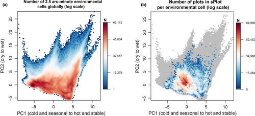

**Figure 2**

Distribution of vegetation plots from sPlot 2.1 in the global environmental space. Comparison of the distribution of all terrestrial 2.5 arc-minute cells (a) and plots in sPlot 2.1 (b) in the principal component analysis (PCA) space defined on 30 environmental (climate and soil) variables. The PCA space was divided into a 100 × 100 regular grid. For each element of this grid, the graphs show the number of 2.5 arc-minute cells (a) and plots (b), respectively. Colors refer to the logarithm of number of plots, with the legend showing untransformed number of plots. The first and second PCA axis explained 48.6% and 27.3% of the total variance

We linked all vegetation plots to two global biome classifications. We used the World Wildlife Fund (WWF) spatial information on terrestrial ecoregions (Olson et al., 2001) to assign plots to one of the 867 ecoregions, 14 biomes and eight biogeographic realms. The WWF approach is based on a bottom-up expert system using various regional biodiversity sources to define ecoregions, which in turn are grouped into realms and biomes (Olson et al., 2001). In addition, we created a shapefile for the ecozones defined by Schultz (2005) to represent major biomes in response to global climatic variation. Since these zones are climatically heterogeneous in mountain regions, we differentiated an additional “alpine” biome for mountain areas above the lower mountain thermal belt, as defined in the classification of world mountain regions by Körner et al. (2017). This resulted in a distinction of 10 major biomes (Figure S4.5 in Appendix S4), whose shapefile is freely available (Appendix S5).

## 3 CONTENT OF SPLOT 2.1

### 3.1 Plot community data

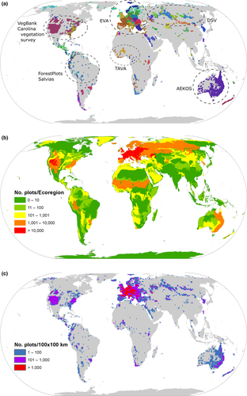

**Figure 3**

Global coverage of sPlot 2.1. (a) Contributing databases identified by different colours with indication of the two data aggregators (EVA, TAVA) and a few particularly large individual databases; (b) available plot numbers per WWF Ecoregion; and (c) available plot density in grid cells of 100 km × 100 km

Vascular plant richness per plot ranges from 1 to 723 species (median = 17 species). The most frequent richness class is between 20 and 25 species (Figure S2.3 in Appendix S2). Plot size is reported in 65.4% of plots, ranging from <1 m<sup>2</sup> to 25 ha, with a median of 36 m<sup>2</sup>. While forest plots have plot sizes ≥100 m<sup>2</sup>, and in most cases ≤1,000 m<sup>2</sup>, non-forest plots range between 5 and 100 m<sup>2</sup> (Figure S2.4 in Appendix S2). When using these size ranges, forest plots tend to be richer in species (Figure 4a). The fact that the gradient in richness found in our plots was at least one order of magnitude stronger than differences that could be expected by the differences in plot size prompted us to produce the first global maps of plot-scale species richness, separately for forests and non-forests (Figure 4a). While plots with complete vascular species composition are largely lacking from the wet tropics, for the remaining biomes the plot-scale richness data do not show the typical latitudinal richness gradient in either formation. Particularly species-rich forests are found in the wet subtropics (such as SE United States, Taiwan and the East coast of Australia) as well as in some mountainous regions of the nemoral and steppic biomes of Eurasia. Likewise, non-forest communities have a particularly high mean vascular plant species in mountainous regions of the nemoral and steppic biomes of Eurasia.

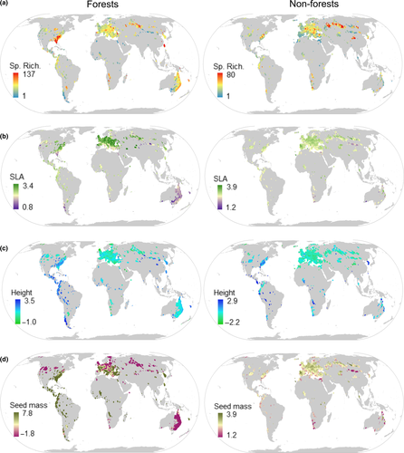

**Figure 4**

Examples of global community-level patterns that can be derived from (a) sPlot alone and (b–d) sPlot combined with TRY, here shown as raw data averaged by 1-degree grid cells. There are only a very few cells (142 out of 2633) comprising only a single plot. For the maps, only plots with full vascular species composition and spatial accuracy <5 km were used. They are based on 148,474 and 218,051 plots for forests and non-forests, respectively. Note that these maps are not corrected for biases caused by the facts that not all community types were recorded in all grid cells and that plot sizes as well as the fraction of species with available trait data varied spatially. Maps show patterns of (a) fine-grain alpha diversity, expressed as vascular plant species richness (only plots with plot sizes of 100–1000 m² for forests and 5–100 m² for non-forests); (b) community-weighted means (CWMs) for log<sub>e</sub>-transformed trait values of specific leaf area (SLA, m<sup>2</sup>/kg); (c) plant height (m); and (d) seed mass (mg)

### 3.3 Functional information

The proportion of species with trait information increases with the species’ frequency in plots. Gap-filled trait information is available for 77.2% and 96.2% for taxa that occurred in more than 100 and 1,000 plots, respectively. Trait coverage is similar across biomes (Figure S8.8 in Appendix S8). Across all biomes, the proportion of species for which gap-filled trait data are available increases with the species’ frequency across plots. Compared to gap-filled data, trait coverage for the original trait data is considerably lower, being highest for height, seed mass, leaf area and specific leaf area (SLA, Figure S8.9 in Appendix S8).

## 4 DATA USAGE

The sPlot database (the vegetation-plot data, including the environmental information for each plot and the species phylogeny) is released in fixed versions to allow reproducibility of results, but also due to the enormous effort needed for data integration and harmonization and for updating the phylogeny. By delivering few fixed versions while keeping older versions available, the sPlot consortium ensures that the same data can be used in parallel projects and that the data underlying a specific study remain accessible in the future, thus allowing re-analysis. Each new version will be matched to the current TRY database.

Data access to sPlot is regulated by the Governance and Data Property Rules ( www.idiv.de/sPlot) to ensure a fair balance between the interests of data contributors and data analysts. In brief, the sPlot Rules state that: (a) all contributing vegetation-plot databases become members of the sPlot consortium, represented by their custodian and deputy custodian; (b) vegetation-plot data contributed to sPlot remain the property of the data contributors and can be withdrawn at any time except for approved projects; (c) other scientists (e.g., data managers or participants of the sPlot workshops) with particular responsibilities may also be appointed as personal members to the sPlot consortium; (d) sPlot data can be requested for projects that involve at least one member of the sPlot consortium; (e) whenever a project has been proposed, all sPlot consortium members will be informed and can declare their interest in becoming co-authors of manuscripts resulting from this project and then becoming actively involved in data evaluation and writing; and (f) if also the matched gap-filled or original trait data from TRY are requested for a project, likewise members from the TRY consortium can opt-in as co-authors. The sPlot database is, therefore, available according to a ‘give-and-receive’ system. Moreover, the data are available to any researcher by establishing a collaboration that includes and is supported by at least one sPlot consortium member.

The sPlot consortium is governed by a Steering Committee elected by all consortium members for two-year, renewable terms. Project proposals can be submitted to the Steering Committee, which ensures that the sPlot Rules are followed and redundant work between overlapping projects is avoided. The lists of databases, sPlot consortium members and the Steering Committee members are updated regularly on the sPlot website, as are the sPlot Rules and the list of approved projects.

## 5 EXPECTED IMPACT AND LIMITATIONS

The main aim of the sPlot database is to catalyze a collaborative network for understanding global diversity patterns of plant communities in space and time. sPlot provides a unique, integrated global repository of data that would otherwise be fragmented in unconnected and structurally inconsistent databases at regional, national or continental levels. Together with the provision of harmonized phylogenetic, functional and environmental information, sPlot allows, for the first time, global analyses of plant community data. Compared to approaches using data aggregated from species occurrences in grid cells, sPlot will significantly advance ecological analyses and future interdisciplinary research in at least four different ways.

1. Using sPlot, one can predict the species that can co-exist in a community and also the frequencies of their co-occurrence (Breitschwerdt, Jandt, & Bruelheide, 2015) or niche overlap (Broennimann et al., 2012). In addition, emerging tools such as Markov networks can be used to infer strengths of interspecific interactions (Harris, 2016). When investigating community assembly rules, the same information can be used to derive species pools for specific vegetation types (de Bello et al., 2016; Karger et al., 2016; Lewis, Szava-Kovats, & Pärtel, 2016). Moreover, the co-occurrence data from sPlot can be used to address fundamental patterns and drivers of plant invasions better than information on large geographic entities (e.g., van Kleunen et al., 2015) alone could.
2. sPlot data can be aggregated across all types of plots, by grid cells, ecoregions, environment, or even vegetation type or formation. Furthermore, replicated plots within grid cells, ecoregions, or any other subdivision of environmental conditions or vegetation types allow users to derive measures of compositional differences between plant communities within grid cells (= beta diversity; Table 1). Thus, the community data are an important complement to regional-scale species occurrence data (e.g., Enquist et al., 2016; Kreft & Jetz, 2007).
3. sPlot data provide information on the proportion of species in a community (in terms of cover, basal area, frequency). When combined with functional trait information, relative abundance of species allows calculation of community abundance-weighted mean trait values (Bruelheide et al., 2018). Information on the relative contribution of species to a community-aggregated trait value is particularly necessary when traits are used as proxies for vegetation functions and processes, allowing to test, among other things, the mass ratio hypothesis (Garnier et al., 2004; Grime, 1998) and to assess the roles of divergent traits (Díaz et al., 2007; Kröber et al., 2015).
4. Plant species within plots can be linked to traits that predict interactions with organisms from other trophic groups, both below-ground (mycorrhizae, soil decomposers) and above-ground (herbivores and pollinators). This will allow linking vegetation plot information to ecosystem processes and services such as pest control, pollination and nutrient cycling (e.g., de Bello et al., 2010).

Despite the large amount of available data and its potential suitability for global research, a number of limitations must be considered by future users of sPlot, such as (a) biases towards certain regions and communities, (b) near-complete lack of plots with complete vascular plant species composition for certain regions (e.g., the wet tropics), (c) identification or sampling errors by the surveyors and incomplete records because the detection of some species may be precluded in certain seasons by their phenology, (d) taxonomic uncertainty, particularly in the tropics, (e) strongly varying plot sizes employed in different studies and regions, (f) lack of trait measures at the plot level. For example, patterns of diversity components are typically affected by grain size. This means that using sPlot data for such studies either requires filtering for plots with identical or at least similar size or accounting for the plot-size effects in the statistical model. In addition, analyses of functional diversity with sPlot data are limited by the absence of trait data for a (small) portion of the species and by the lack of plot-specific trait measures. Furthermore, the non-random and geographically and ecologically very unequal distribution of the plots contained in sPlot call for stratified resampling to balance records of different environments (e.g., stratified by climate, Figure 2) or physiognomic formations (Figure 4). Users of sPlot need to be aware of these and other limitations and to correct potential biases for their specific research question.

## 6 CONCLUSION

sPlot is a unique global database of plant community records sampled with relatively similar methods widely used in vegetation ecology. The integration of co-occurrence data into a unified database that can be directly linked to environmental, functional and phylogenetic information, makes sPlot an unprecedented and essential tool for analyzing global plant diversity, the structure of plant communities and the co-occurrence of plant species. The compatibility of this consolidated database with other global databases, e.g., via a joint taxonomic backbone with TRY and the Global Naturalized Alien Flora (GloNAF; van Kleunen et al., 2015) (via taxon names), or via standardized geo-reference with databases of environmental information such as CHELSA, WorldClim or SoilGrids (Bruelheide et al., 2018), facilitates data integration and creates new research opportunities. The adaptive management of the database employed by the sPlot consortium allows regular incorporation of new data, resulting in a dynamic platform for storing and analyzing the most comprehensive compilation of plant community data worldwide.

## ACKNOWLEDGEMENTS

We are grateful to thousands of vegetation scientists who sampled vegetation plots in the field or digitized them into regional, national or international databases. We also appreciate the support of the German Research Foundation for funding sPlot as one of the iDiv (DFG FZT 118) research platforms, and the organization of three workshops through the sDiv calls. We acknowledge this support with naming the database “sPlot”, where the “s” refers to the sDiv synthesis workshops. The study was supported by the TRY initiative on plant traits ( http://www.try-db.org). For all further acknowledgements see Appendix S10. We thank Meelis Pärtel for his very fast and constructive feedback on an earlier version of this manuscript.

## AUTHOR CONTRIBUTIONS

H.Bru. had the original idea and led the consortium from the start, while O.Pu. and J.D. coordinated the sPlot workshops. J.D., S.M.H. and U.J. compiled the databases to be included in sPlot. J.D. and later B.J.-A. and F.M.S. coordinated the network and the database. O.P. prepared the taxonomic and phylogenetic data. S.M.H programmed the Turboveg software. B.Sa., F.J., H.Bru., J.D., J.K., M.Ch., and V.D.P. organized the network in the Steering Committee. B.J.-A. and H.Bru. led the writing together with J.D. and input from S.M.H., O.Pu., M.Ch., F.J., J.K., V.D.P., B.Sa., I.Au., I.B., R.K.P., R.F., S.H., U.J., J.L., G.P., F.M.S., M.S., F.S. and M.W. The rest of authors (ordered alphabetically) contributed the plot and trait data. All authors agreed with the final manuscript.

## DATA ACCESSIBILITY

The data contained in sPlot (the vegetation-plot data complemented by species phylogeny and environmental information) are available on request, through contacting any of the consortium members for submitting a paper proposal. The proposals should follow the Governance and Data Property Rules of the sPlot Working Group, which are available on the sPlot website ( www.idiv.de/sPlot). After acceptance, the respective data will be provided. In addition to the plot data, CWMs and CWVs of 18 plant traits are available for every plot.